# BBC - Laboratoires 3-4

Je ne suis pas très satisfait, pour des candidats comme MBD4, CHRNA3, IKZF1, GPX1 ou encore ANKHD1-EIF4EBP3, la différence ne se voit pas forcément à l'oeil, après, il faut se demander si nous voulons de l'interprêtabilité ou de la précision, si la mchine peut différencier aussi bien, je ne suis pas contre, pour résoudre ce problème d'interprétabilité, je conseillerais une distance minimale entre la moyenne des cancereuses et celles des normales

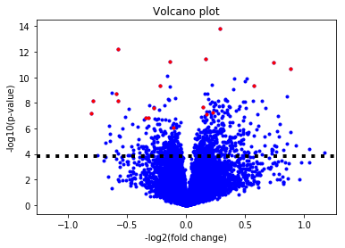

```python
stats.volcano_plot(data[1:,2:],desired_profile,idx=idx_sg_final)
```

## 3. Construire un classificateur pour développer un outil diagnostique

Dans la première partie du labo, vous avez analysé un set de données transcriptomiques afin d'identifier des gènes exprimés différentiellement dans la condition malade vs. normale. Ces gènes constituent des candidats comme cibles d'un nouveau médicament à développer. Dès à présent, ce sera aux biologistes de reprendre la main afin d'essayer d'identifier une molécule capable d'agir spécifiquement sur un ou plusieurs de ces gènes et de tester le potential thérapeutique expérimentalement.

Par ailleurs, avec un tel set de données, l'on pourrait aussi envisager de construire un classificateur à leucémie AML, afin, par exemple, de diagnostiquer la maladie le plus tôt possible. En effet, l'on pourrait imaginer qu'à l'aide de quelques données transcriptomiques d'un patient (l'expression des 19 gènes que vous venez d'identifier), l'on pourrait prédire s'il est atteint de leucémie AML ou pas. Dans ce cas, on dirait que ces 19 gènes constituent des biomarqueurs de l'AML.

**→ Afin d'entraîner un modèle "k-Nearest-Neighbors" (kNN), commencez par définir la matrice X des données et le vecteur y contenant les labels (1 si AML, 0 si normal). Définissez aussi ces matrices pour le test set, qui n'a pas été utilisé jusqu'ici pour identifier les biomarqueurs.**

```python
# train set
X = data[idx_sg_final+1,2:]
# il faut transposer la matrice, car SVM s'attend a recevoir les features en colonnes et non en lignes
X = np.transpose(X)
X = np.array(X,dtype=float)
y = [1 if id_cond[s]=='AML' else 0 for s in data[0,2:]]

# test set
X_test = data_test[idx_sg_final+1,2:]
X_test = np.transpose(X_test)
X_test = np.array(X_test,dtype=float)
y_test = [1 if id_cond[s]=='AML' else 0 for s in data_test[0,2:]]
```

**3.1** Discutez brièvement l'importance du fait que les données du test-set n'aient pas été utilisées jusqu'à présent.

[source](https://towardsdatascience.com/train-test-split-and-cross-validation-in-python-80b61beca4b6)

**→ Utilisez la librairie [scikit-learn](http://scikit-learn.org/stable/) pour construire un premier classificateur [k-nearest neighbors](http://scikit-learn.org/stable/modules/neighbors.html) dont les "features" seraient l'expression des gènes identifiés à la section 2.** A noter que les valeurs d'expression prennent des valeurs similaires quelque soit le gène; il n'est donc pas nécessaire de normaliser les "features" avant d'entraîner le modèle.

```python
from sklearn import neighbors

def kNN_classifier(X,y,X_test,y_test):

    # train de SVM classifier
    clf = neighbors.KNeighborsClassifier()
    clf.fit(X, y)

    # predict on the test set
    pred_kNN = clf.predict(X_test)

    # return score
    score = clf.score(X_test,y_test)
    return score

score = kNN_classifier(X,y,X_test,y_test)
print('Le classificateur kNN fait '+str(round(100*score))+'% de prédictions correctes (sur le test set).')
```

```
Le classificateur kNN fait 100.0% de prédictions correctes (sur le test set).
```

Comme vous pouvez le voir, ces 19 biomarqueurs sont suffisants pour classifier correctement tous les patients du test set. Une manière visuelle de comprendre ce résultat est de représenter la matrice de distance entre chaque condition, en n'utilisant que les 19 gènes sélectionnés.

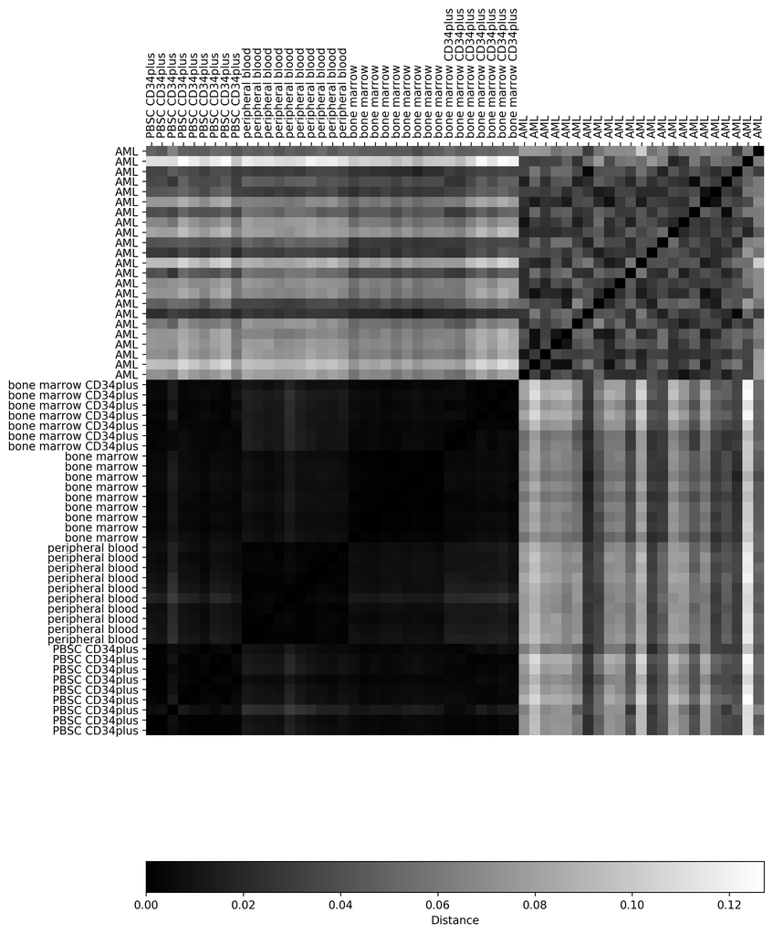

```python
import scipy.spatial.distance as ssd
import matplotlib

# calculate distance between any two conditions in X
D = ssd.pdist(X,'cosine')
Ds = ssd.squareform(D)

# plot
fig, ax = plt.subplots(num=None,figsize=(10,14),dpi=250)
heatmap = ax.pcolor(Ds, cmap=plt.cm.gray)

ax.set_xticks(np.arange(Ds.shape[1])+0.5, minor=False)
ax.set_yticks(np.arange(Ds.shape[0])+0.5, minor=False)

ax.set_frame_on(False)
ax.xaxis.tick_top()
ax.grid(False)
plt.xlim([0,np.shape(Ds)[1]])

labels = [id_cond[s] for s in data[0,2:]]
ax.set_yticklabels(labels, minor=False)
ax.set_xticklabels(labels, minor=False)

plt.xticks(rotation=90) # rotate xlabels
matplotlib.rcParams['xtick.labelsize'] = 10

cbar = fig.colorbar(heatmap, orientation='horizontal')
cbar.set_label('Distance')
```

**3.2** Au vu de la matrice ci-dessus, est-ce que les patients atteints de AML sont plus similaires entre eux que les patients sains? Justifiez brièvement. Sur quelle ligne (de la matrice) se trouve le patient atteint de AML dont le profil d'expression est le plus différent de l'expression "normale"?

Non, les patient atteints de AML sont disparates alors que les couleurs chez les pateints sains restent homogène. La 2ème ligne

Vous allez à présent réduire le nombre de biomarqueurs et voir quel est le nombre minimum de biomarqueurs nécessaire pour prédire correctement la classe des patients (et réduire ainsi les coûts associés à l'utilisation de biomarqueurs).

**3.3** Générez un tableau qui contient le score de prédiction de chaque paire de biomarqueurs (parmi la liste idx_sg_final). Représentez graphiquement ce tableau à l'aide d'un heatmap. Discutez brièvement les résultats obtenus.

```python
data[0,2:]
```

```
array(['GSM240500', 'GSM240501', 'GSM240502', 'GSM240503', 'GSM240504',
       'GSM240506', 'GSM240507', 'GSM240508', 'GSM240509', 'GSM240430',
       'GSM240431', 'GSM240432', 'GSM240433', 'GSM240494', 'GSM240495',
       'GSM240496', 'GSM240497', 'GSM240498', 'GSM240499', 'GSM239324',
       'GSM239326', 'GSM239328', 'GSM239329', 'GSM239331', 'GSM239332',
       'GSM239333', 'GSM239334', 'GSM239335', 'GSM239170', 'GSM239338',
       'GSM239339', 'GSM239340', 'GSM239341', 'GSM239342', 'GSM239344',
       'GSM239371', 'GSM239487', 'GSM239489', 'GSM239497', 'GSM239520',
       'GSM240427', 'GSM239345', 'GSM239346', 'GSM239363', 'GSM239460',
       'GSM239485', 'GSM239488', 'GSM239490', 'GSM239491', 'GSM239493',
       'GSM239495', 'GSM239496', 'GSM239498', 'GSM239516', 'GSM239580',
       'GSM240405', 'GSM240406', 'GSM240429'], dtype='<U27')
```

```python
#preparation du tableau
N_final_candidat = len(idx_sg_final)
scores = np.empty((N_final_candidat,N_final_candidat),dtype=float)
```

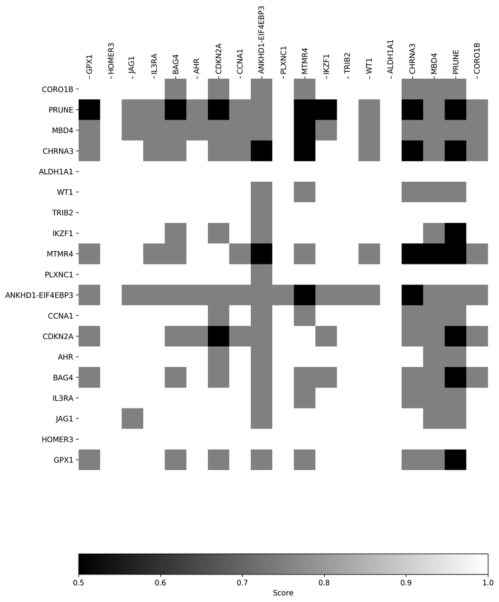

```python
for i in range(N_final_candidat):
    for j in range(N_final_candidat):

        train_set = []

        train_set.append(data[idx_sg_final[i]+1,2:])
        train_set.append(data[idx_sg_final[j]+1,2:])

        # train set
        X = train_set
        # il faut transposer la matrice, car SVM s'attend a recevoir les features en colonnes et non en lignes
        X = np.transpose(X)
        X = np.array(X,dtype=float)
        y = [1 if id_cond[s]=='AML' else 0 for s in data[0,2:]]


        test_set = []

        test_set.append(data_test[idx_sg_final[i]+1,2:])
        test_set.append(data_test[idx_sg_final[j]+1,2:])

        # test set
        X_test = test_set
        X_test = np.transpose(X_test)
        X_test = np.array(X_test,dtype=float)
        y_test = [1 if id_cond[s]=='AML' else 0 for s in data_test[0,2:]]

        scores[i][j] = kNN_classifier(X,y,X_test,y_test)

# plot
fig, ax = plt.subplots(num=None,figsize=(10,14),dpi=250)
heatmap = ax.pcolor(scores, cmap=plt.cm.gray)

ax.set_xticks(np.arange(scores.shape[1])+0.5, minor=False)
ax.set_yticks(np.arange(scores.shape[0])+0.5, minor=False)

ax.set_frame_on(False)
ax.xaxis.tick_top()
ax.grid(False)
plt.xlim([0,np.shape(scores)[1]])

labels = data[idx_sg_final+1, 1]
ax.set_yticklabels(labels, minor=False)
ax.set_xticklabels(labels, minor=False)

plt.xticks(rotation=90) # rotate xlabels
matplotlib.rcParams['xtick.labelsize'] = 10

cbar = fig.colorbar(heatmap, orientation='horizontal')
cbar.set_label('Score')
```

```python
sets = set()

for i in range(N_final_candidat):
    for j in range(N_final_candidat):
        sets.add(scores[i][j])
sets
```

```
{0.5, 0.75, 1.0}
```

Il est de bonne pratique de toujours comparer la performance d'un classificateur avec celle d'un "dummy estimator", qui utilise le même nombre de biomarqueurs mais choisis au hasard. Ceci nous donne alors un "baseline" de la performance minimum à dépasser si l'on veut faire mieux que le hasard.

**3.4** Calculez le score moyen sur 100 expériences d'un dummy estimator qui utiliserait 19 gènes choisis au hasard parmi la liste de 22283 gènes. Répétez la même opération en ne sélectionnant que 2 gènes au hasard parmi la liste des 22283 gènes.

```python
from random import shuffle

N_iterations = 100
N_genes_total = 22283
N_genes = 19

to_randomize = list(range(N_genes_total))

scores = []

for iteration in range(N_iterations):

    shuffle(to_randomize)

    idx = to_randomize[:N_genes]
    idx = np.array(idx)
    # train set
    X = data[idx+1,2:]
    # il faut transposer la matrice, car SVM s'attend a recevoir les features en colonnes et non en lignes
    X = np.transpose(X)
    X = np.array(X,dtype=float)
    y = [1 if id_cond[s]=='AML' else 0 for s in data[0,2:]]

    # test set
    X_test = data_test[idx+1,2:]
    X_test = np.transpose(X_test)
    X_test = np.array(X_test,dtype=float)
    y_test = [1 if id_cond[s]=='AML' else 0 for s in data_test[0,2:]]

    scores.append(kNN_classifier(X,y,X_test,y_test))

print("Score moyen avec {} gènes choisis au hasard : {}".format(N_genes, np.mean(scores)) )
```

```
Score moyen avec 19 gènes choisis au hasard : 0.83
```

```python
N_iterations = 100
N_genes_total = 22283
N_genes = 2

to_randomize = list(range(N_genes_total))

scores = []

for iteration in range(N_iterations):

    shuffle(to_randomize)

    idx = to_randomize[:N_genes]
    idx = np.array(idx)
    # train set
    X = data[idx+1,2:]
    # il faut transposer la matrice, car SVM s'attend a recevoir les features en colonnes et non en lignes
    X = np.transpose(X)
    X = np.array(X,dtype=float)
    y = [1 if id_cond[s]=='AML' else 0 for s in data[0,2:]]

    # test set
    X_test = data_test[idx+1,2:]
    X_test = np.transpose(X_test)
    X_test = np.array(X_test,dtype=float)
    y_test = [1 if id_cond[s]=='AML' else 0 for s in data_test[0,2:]]

    scores.append(kNN_classifier(X,y,X_test,y_test))

print("Score moyen avec {} gènes choisis au hasard : {}".format(N_genes, np.mean(scores)) )
```

```
Score moyen avec 2 gènes choisis au hasard : 0.5775
```

**3.5** Discutez brièvement les résultats obtenus avec 19 ou 2 gènes choisis au hasard.

À ma plus grande surprise, 2 gènes hasard semble quelques peu efficace, mais 19 gènes au hasard reste meilleur.

## 4. Pour aller plus loin… Données "-omiques"

Dans ce labo, vous avez utilisé des données de type transcriptomique (expression des gènes). Il existe cependant beaucoup d'autres types de données "-omiques" qui peuvent être utilisées pour identifier des biomarqueurs, des cibles thérapeutiques potentielles et pour construire des classificateurs.

**4.1** En vous renseignant sur internet, mentionnez au moins deux autres technologies "omics" utilisées en bioinformatique et décrivez-les, avec leurs utilisations principales et limitations (450 mots maximum au total).

[Relation entre génomique, transcriptomique et protéomique](https://fr.wikipedia.org/wiki/Relation_entre_g%C3%A9nomique,_transcriptomique_et_prot%C3%A9omique)

[Omics-Based Strategies in Precision Medicine: Toward a Paradigm Shift in Inborn Errors of Metabolism Investigations](https://www.ncbi.nlm.nih.gov/pmc/articles/PMC5037827/)

[NCBI search](https://www.ncbi.nlm.nih.gov/pmc/?term=biomarkers+target+classifiers+omics)